# ANOVA 1 e 2 fatores

Prof J van Melis

29 de abril de 2018

## ANOVA

Com o objetivo de comparar as mC)dias entre dois ou mais grupos, a ANOVA (anC!lise de variC"ncia, do inglC*s **AN**alysis **O**f **VA**riance) C) uma boa opC'C#o.

Ela C) um teste paramC)trico, portanto:

- Leva em consideraC'C#o os parC"metros das amostras: mC)dia e desvio-padrC#o
- A distribuiC'C#o dos dados a serem comparados devem seguir distribuiC'C#o normal
- AlC)m disso, os dados contC-nuos (mensurados) devem apresentar homocedasticidade (variC"ncias semelhantes) entre os grupos comparados

A fC3rmula geral da ANOVA C) relacionar uma variC!vel dependente contC-nua (variC!vel quantitativa contC-nua) com uma variC!vel qualitativa (ordinal ou categC3rica). Portanto, se a sua variC!vel $Y$ resposta (dependente) for uma variC!vel contC-nua (numC)rica) e vocC* quer relacionar com uma variC!vel independente que C) qualitativa ($X$), a ANOVA pode ser uma boa opC'C#o.

$$Y \sim X$$

Sendo: $X$ Fator (ordinal ou categC3rico) $Y$ NumC)rico ($\sim N (\mu, \sigma^2)$)

ANOVA tambC)m C) um **teste de hipC3teses**, como o teste t de Student, e a hipC3tese nula a ser testada C): **H0**: As mC)dias sC#o iguais entre as categorias do fator analisado; E a hipC3tese alternativa C): **H1**: Uma ou mais mC)dias se distingue entre as categorias do fator analisado.

Ou seja, quando o seu teste de hipC3tese apontar um *p-valor* baixo (normalmente o $\alpha$ C) de 5%, ou seja, se p-valor < 5%), podemos rejeitar H0 e aceitamos a H1.

Ao rejeitarmos a H0, inferimos que a variC!vel categC3rica tem influC*ncia na variaC'C#o da mC)dia da variC!vel contC-nua (numC)rica) analisada.

Por exemplo, vocC* quer analisar se a variC!vel contC-nua [pressC#o sanguC-nea](https://www.mdsaude.com/2014/08/pressao-arterial-normal.html) (tambC)m chamada de **pressC#o arterial**, divide-se em dois valores *sistC3lica* e *diastC3lica*) varia entre as categorias da variC!vel **dieta** (no caso, temos trC*s categorias: *veganos*, *vegetarianos* e *onC-voros*).

$$Pressao \sim Dieta$$

Para esse *b estudob* , utilizaremos somente a pressC#o sistC3lica, que C) o maior valor quando nC3s mensuramos a nossa pressC#o (a popular 12/8), mas em unidades de mm/Hg. A H0 portanto C): As medC-as das pressC5es entre as trC*s categorias do fator **dieta** C) igual
$$\mu_{veganos} = \mu_{vegetarianos} = \mu_{onC-voros}$$

Para esse teste, utilizaremos valores aleatC3rios que serC#o gerados a seguir no [R](https://cran.r-project.org/) (linhas de comando a seguir):

```r
set.seed(42)
dados <-  data.frame(dieta = c(rep("vegano", 30),
                              rep("vegetariano", 30),
                              rep("onivoro", 30)),
                     sistole = c(115+rnorm(30, sd=5),
                                 120+rnorm(30, sd=4),
                                 125+rnorm(30, sd=10)))
```

Lembre-se que esses dados foram totalmente gerados de maneira aleatC3ria por um professor que defende um consumo menor de carne (mas que gosta de queijo)!

Para efetuar o teste, avalie os pressupostos do teste com os seus dados:

1. DistribuiC'C#o normal.

```r
tapply(X = dados$sistole,
      INDEX = dados$dieta,
      FUN = shapiro.test)
```

```
## $onivoro
##
##  Shapiro-Wilk normality test
##
## data:  X[[i]]
## W = 0.9579, p-value = 0.2735
##
##
## $vegano
##
##  Shapiro-Wilk normality test
##
## data:  X[[i]]
## W = 0.96209, p-value = 0.35
##
##
## $vegetariano
##
##  Shapiro-Wilk normality test
##
## data:  X[[i]]
## W = 0.93428, p-value = 0.06386
```

Os trC*s grupos seguem distribuiC'C#o normal segundo o teste de Shapiro-Wilk (nC#o rejeitamos a hipC3tese nula de que os dados seguem distribuiC'C#o normal, p>0.05).

2. Verificar homocedasticidade dos dados

```r
tapply(X = dados$sistole,
      INDEX = dados$dieta,
      FUN = var)
```

```
##     onivoro      vegano vegetariano
##    61.34608    39.37739    17.64190
```

Olhando os dados, nC#o hC! nenhum que apresenta variC"ncia 4 vezes maior que a variC"ncia de outro grupo.

Podemos executar um teste de variC"ncia, podendo ser o teste de Bartlett:

```r
bartlett.test(sistole ~ dieta, dados)
```

```
##
##  Bartlett test of homogeneity of variances
##
## data:  sistole by dieta
## Bartlett's K-squared = 10.439, df = 2, p-value = 0.005409
```

Pelo teste de Bartlett, que C) bem rC-gido, rejeitamos a nossa hipC3tese nula de que as variC"ncias sC#o iguais.

```
O que fazer nesse caso?
```

3. Verifique se os dados estC#o balanceados. Eles devem apresentar tamanhos amostrais semelhantes:

```r
table(dados$dieta)
```

```
##
##     onivoro      vegano vegetariano
##          30          30          30
```

4. Executar ANOVA

Podemos executar pelo R por quatro principais maneiras: A. Usando a funC'C#o `aov()` diretamente, depois vendo o seu `summary()`:

```r
anova_a<-aov(sistole ~ dieta, dados)
anova_a
```

```
## Call:
##    aov(formula = sistole ~ dieta, data = dados)
##
## Terms:
##                    dieta Residuals
## Sum of Squares  2058.186  3432.596
## Deg. of Freedom        2        87
##
## Residual standard error: 6.281331
## Estimated effects may be unbalanced
```

```r
summary(anova_a)
```

```
##             Df Sum Sq Mean Sq F value   Pr(>F)
## dieta        2   2058  1029.1   26.08 1.34e-09 ***
## Residuals   87   3433    39.5
## ---
## Signif. codes:  0 '***' 0.001 '**' 0.01 '*' 0.05 '.' 0.1 ' ' 1
```

B. Usando a funC'C#o `aov()` em objeto `lm`, que C) construC-do a partir da funC'C#o `lm()`, depois vendo o quadro resumo com a funC'C#o `summary()`:

```r
mod <- lm(sistole ~ dieta, dados)
anova_b<-aov(mod)
summary(anova_b)
```

```
##             Df Sum Sq Mean Sq F value   Pr(>F)
## dieta        2   2058  1029.1   26.08 1.34e-09 ***
## Residuals   87   3433    39.5
## ---
## Signif. codes:  0 '***' 0.001 '**' 0.01 '*' 0.05 '.' 0.1 ' ' 1
```

C. Usando a funC'C#o `anova()` no objeto `lm`

```r
anova_c <- anova(mod)
anova_c
```

```
## Analysis of Variance Table
##
## Response: sistole
##           Df Sum Sq Mean Sq F value    Pr(>F)
## dieta      2 2058.2 1029.09  26.083 1.335e-09 ***
## Residuals 87 3432.6   39.46
## ---
## Signif. codes:  0 '***' 0.001 '**' 0.01 '*' 0.05 '.' 0.1 ' ' 1
```

D. Usando funC'C#o `Anova()` do pacote `car` em um objeto da classe `lm`:

```r
if(!require(car)){install.packages('car')}
anova_d<-Anova(mod)
anova_d
```

```
## Anova Table (Type II tests)
##
## Response: sistole
##           Sum Sq Df F value    Pr(>F)
## dieta     2058.2  2  26.083 1.335e-09 ***
## Residuals 3432.6 87
## ---
## Signif. codes:  0 '***' 0.001 '**' 0.01 '*' 0.05 '.' 0.1 ' ' 1
```

Em todos os resultados o nosso teste foi significativo (p-valor<0.0001), logo **rejeitamos H0**. Portanto, assumimos a hipC3tese de que a *dieta* tem influC*ncia nos valores mC)dios da pressC#o *sistC3lica*, pois as suas mC)dias se diferem.

5. Analisando seus resC-duos. C interesse realizar um diagnC3stico do teste tambC)m:

A. Analise se os resC-duos apresentam mC)dias em torno do **zero** (linha vermelha deve estar paralela); B. Analise se a variC"ncia dos resC-duos estC#o uniformemente distribuC-dos (amplitude dos pontos) C. Observe valores que sC#o mostrados no R. Isso indica possC-veis *outliers*, sendo os nC:meros as linhas em que eles estC#o localizados na sua tabela (nesse caso: `18`, `81` e `85`):

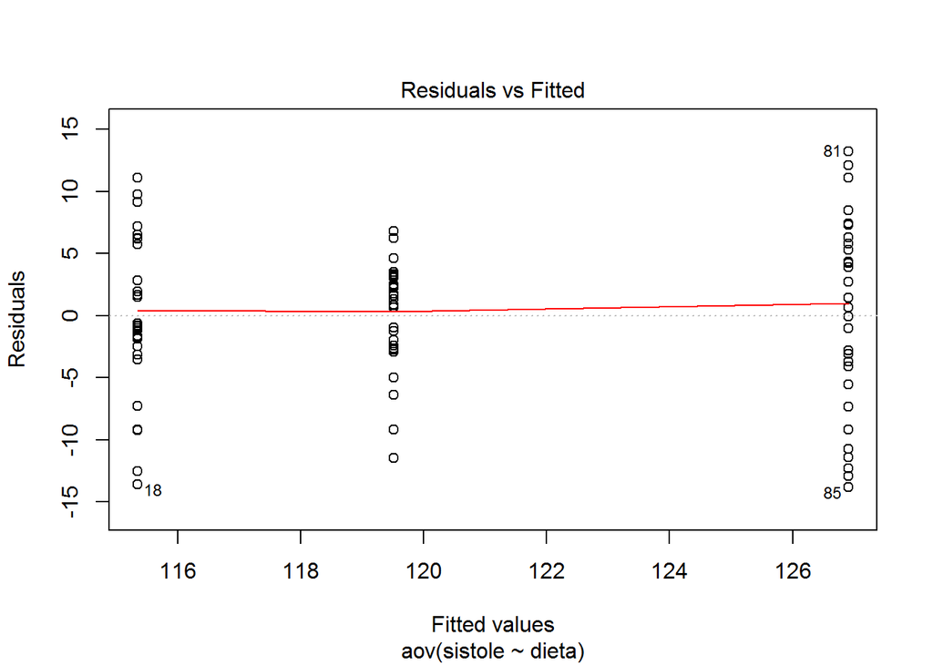

```r
plot(anova_a, which=1)
```

D. Avalie se os resC-duos seguem distribuiC'C#o normal:

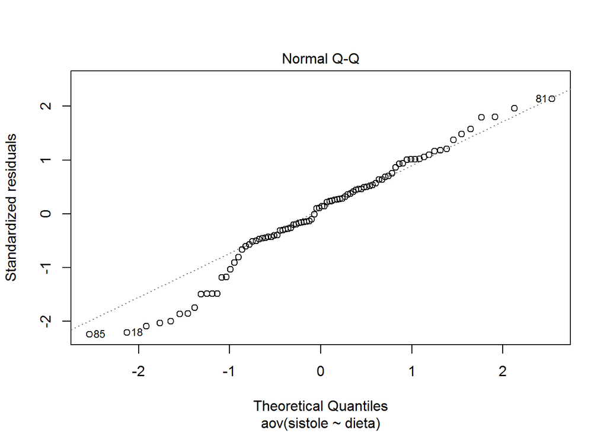

```r
plot(anova_a, which=2)
```

Onde podemos perceber que os resC-duos nC#o mostram uma distribuiC'C#o tC#o prC3xima da normal, pois os menores valores (mais prC3ximos do canto inferior esquerdo) estC#o afastados da reta da distribuiC'C#o normal esperada (linha tracejada da diagonal). Mas o teste de Shapiro-Wilk (`shapiro.test()`) dos resC-duos (extraC-dos pela funC'C#o `residuals()` no objeto `anova_a`) mostra que os resC-duos possuem uma distribuiC'C#o normal (p>0.05):

```r
shapiro.test(residuals(anova_a))
```

```
##
##  Shapiro-Wilk normality test
##
## data:  residuals(anova_a)
## W = 0.9752, p-value = 0.08266
```

6. Se o teste foi significativo, execute um teste *post hoc*. O mais conhecido e utilizado C) o teste de Tukey HSD (*honestly significant differences*).

No nosso caso, o nosso teste foi significativo, pois $F_{2, 87} = 26.083$, com p-valor = $1.35~ 10^-9$, sendo bem menor que o $\alpha$ tradicional (nC-vel de significC"ncia, porcentagem de erro tipo I aceitC!vel) de 5% . Portanto, podemos executar o Teste *post hoc* para verificar **quais mC)dias sC#o diferentes entre si**.

```r
TukeyHSD(anova_a)
```

```
##   Tukey multiple comparisons of means
##     95% family-wise confidence level
##
## Fit: aov(formula = sistole ~ dieta, data = dados)
##
## $dieta
##                           diff         lwr       upr     p adj
## vegano-onivoro      -11.564758 -15.4319853 -7.697531 0.0000000
## vegetariano-onivoro  -7.395326 -11.2625535 -3.528099 0.0000492
## vegetariano-vegano    4.169432   0.3022048  8.036659 0.0314792
```

$$HSD = X_{a}-X_{b}/\sqrt(SSD_{within}/n)$$

E vocC* pode visualizar o teste, com seus valores *upper* e *lower* de confianC'a:

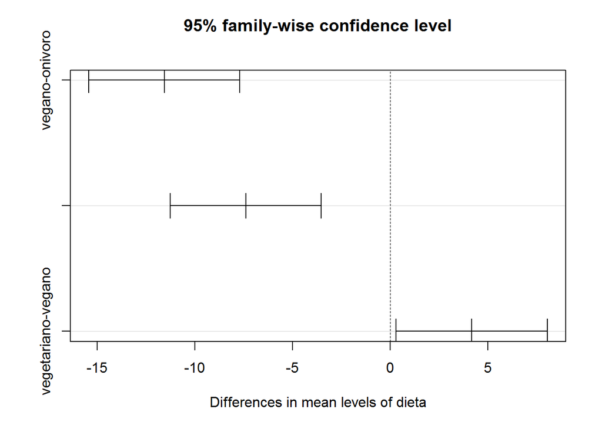

```r
plot(TukeyHSD(anova_a))
```

Como nenhum dos intervalos estC! cruzando a linha da diferenC'a igual a zero (linha tracejada na vertical), as diferenC'as entre os grupos (`vegano`,`vegetariano` e `onivoro`) do fator `dieta` apresentam mC)dias distintas de pressC#o `sistolica`, entre todos (nenhuma mC)dia C) igual a outra mC)dia)

para visualizar o resultado final podemos utilizar o pacote `ggplot2`, que permite uma grande variedade de grC!ficos bonitos:

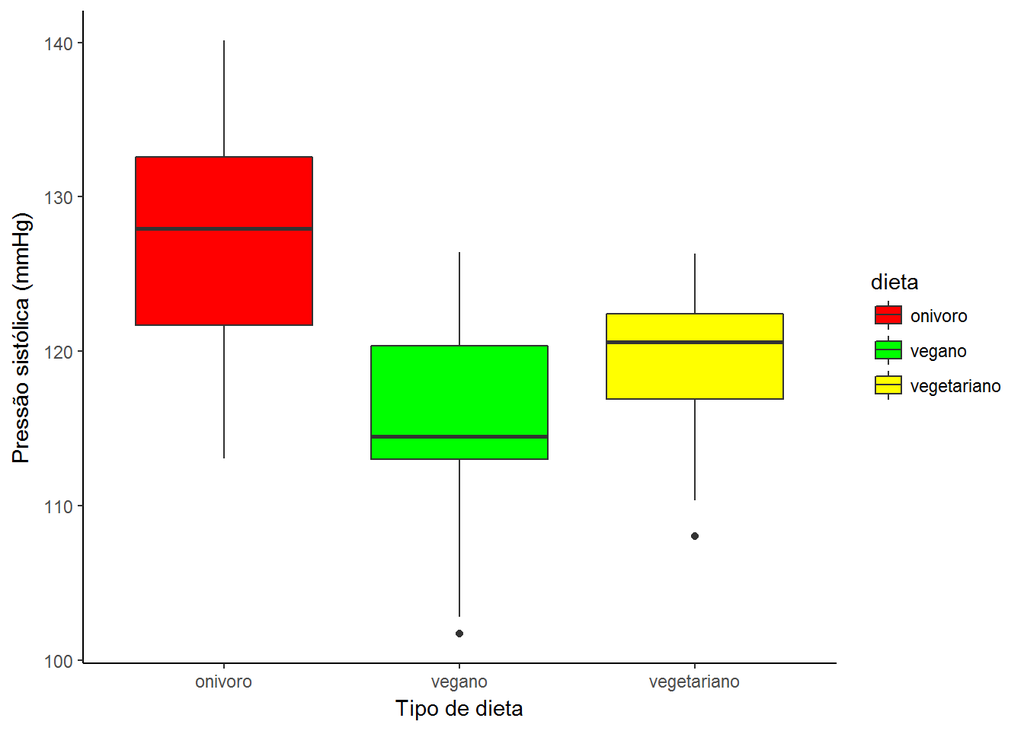

```r
if(!require(ggplot2)){install.packages("ggplot2")}
ggplot(dados, aes(x=dieta, y=sistole, fill=dieta))+
  geom_boxplot()+theme_classic()+ylab("PressC#o sistC3lica (mmHg)")+
  scale_fill_manual(values = c("red", "green", "yellow"))+
  xlab("Tipo de dieta")
```

# ANOVA dois fatores (ANOVA two-way)

Vamos supor que vocC* desconfie que exista mais uma interferC*ncia para a variaC'C#o da mC)dia da pressC#o sistC3lica, que seria o `sexo` da pessoa (`masculino` ou `feminino`).

Criaremos uma coluna a mais, denominada `sexo`, onde existirC#o pessoas do sexo masculino e feminino. SeguirC! uma distribuiC'C#o binomial com probabibilidade 50% de ser `masculino` ou `feminino`.

```r
set.seed(05)
dados$sexo<-rbinom(n=90, size=1, prob=0.5)
dados$sexo <- ifelse(dados$sexo==1, "masculino", "feminino")
```

E serC! efetuado uma ANOVA com dois fatores:

$$Y_{contC-nua} \sim X1_{fator} + X2_{fator} + X1:X2$$

Sendo $X1:X2$ a interaC'C#o entre os fatores $X1$ e $X2$.

Seguiremos os seguintes passos:

1. Verificamos se os fatores se encontram balanceados:

```r
table(dados$dieta, dados$sexo)
```

```
##
##               feminino masculino
##   onivoro           12        18
##   vegano            16        14
##   vegetariano       16        14
```

Parece estar balanceado. Para nos certificarmos disso, executaremos um teste de $\chi^2$:

```r
chisq.test(table(dados$dieta, dados$sexo))
```

```
##
##  Pearson's Chi-squared test
##
## data:  table(dados$dieta, dados$sexo)
## X-squared = 1.4229, df = 2, p-value = 0.4909
```

O teste deu nC#o significativo (p=0.4909), logo nC#o rejeitamos a nossa hipC3tese nula de que **as frequC*ncias sC#o iguais**

2. Testar a normalidade dos dados para ambos os sexos (para o fator `dieta` jC! havia sido realizado):

```r
tapply(X = dados$sistole,
       INDEX = dados$sexo,
       FUN = shapiro.test)
```

```
## $feminino
##
##  Shapiro-Wilk normality test
##
## data:  X[[i]]
## W = 0.97235, p-value = 0.3653
##
##
## $masculino
##
##  Shapiro-Wilk normality test
##
## data:  X[[i]]
## W = 0.97846, p-value = 0.5445
```

3. Testar a homocedasticidade dos dados para ambos os sexos (para o fator `dieta` jC! havia sido realizado):

```r
tapply(X = dados$sistole,
       INDEX = dados$sexo,
       FUN = var)
```

```
##  feminino masculino
##  43.58956  80.18604
```

A variC"ncia de `masculino` foi atC) o dobro da variC"ncia de `feminino` (*rule of thumb* de 4 vezes foi honrada).

```r
bartlett.test(sistole ~ sexo, dados)
```

```
##
##  Bartlett test of homogeneity of variances
##
## data:  sistole by sexo
## Bartlett's K-squared = 3.9599, df = 1, p-value = 0.0466
```

4. Executar ANOVA

Para testar a interaC'C#o entre fatores, vocC* pode escrever o cC3digo da `formula` no R de duas maneiras:

1. `sistole ~ dieta + sexo + dieta:sexo` ou
2. `sistole ~ dieta*sexo` Ambos serC#o entendidos da mesma maneira, mas lembre-se que se vocC* quiser analisar uma ANOVA com um **modelo aditivo**, C) sC3 retirar a porC'C#o da interaC'C#o da `formula`, dessa maneira: `sistole ~ dieta + sexo`

Da mesma maneira que para ANOVA *one-way*, com dois fatores tambC)m pode ser executada de 4 maneiras, mas observe que se os dados estiverem desbalanceados, a funC'C#o `Anova()` do pacote `car` pode resultar em resultados diferentes, principalmente se nC#o houver interaC'C#o entre os fatores:

```r
anova_I <- aov(sistole ~ dieta*sexo, dados)
summary(anova_I)
```

```
##             Df Sum Sq Mean Sq F value   Pr(>F)
## dieta        2   2058  1029.1  26.624 1.11e-09 ***
## sexo         1      6     6.3   0.163    0.687
## dieta:sexo   2    179    89.7   2.321    0.104
## Residuals   84   3247    38.7
## ---
## Signif. codes:  0 '***' 0.001 '**' 0.01 '*' 0.05 '.' 0.1 ' ' 1
```

Para simplificar, serC! mostrado a mais somente pela funC'C#o `car::Anova()`

```r
mod<-lm(sistole ~ dieta*sexo, dados)
anova_II<-car::Anova(mod)
anova_II
```

```
## Anova Table (Type II tests)
##
## Response: sistole
##            Sum Sq Df F value    Pr(>F)
## dieta      2056.4  2 26.6013 1.123e-09 ***
## sexo          6.3  1  0.1632    0.6872
## dieta:sexo  179.4  2  2.3211    0.1044
## Residuals  3246.9 84
## ---
## Signif. codes:  0 '***' 0.001 '**' 0.01 '*' 0.05 '.' 0.1 ' ' 1
```

```r
mod<-lm(sistole ~ dieta*sexo, dados)
anova_III<- car::Anova(mod, type="III")
anova_III
```

```
## Anova Table (Type III tests)
##
## Response: sistole
##             Sum Sq Df   F value  Pr(>F)
## (Intercept) 188515  1 4877.1216 < 2e-16 ***
## dieta          457  2    5.9124 0.00396 **
## sexo            49  1    1.2749 0.26207
## dieta:sexo     179  2    2.3211 0.10443
## Residuals     3247 84
## ---
## Signif. codes:  0 '***' 0.001 '**' 0.01 '*' 0.05 '.' 0.1 ' ' 1
```

5. Avaliar os resC-duos:

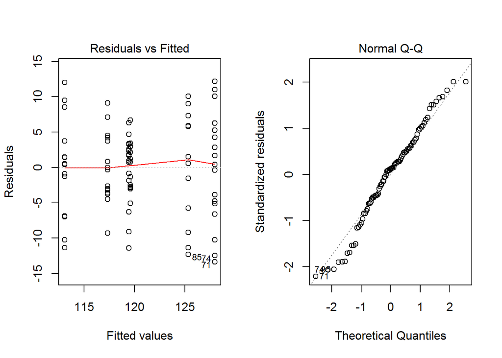

```r
par(mfrow=c(1,2))
plot(anova_I, which=c(1,2))
```

Visualizando os dois grC!ficos, tudo OK!

6. Teste *post hoc* Neste caso, nC#o haveria necessidade de executar um teste post hoc, pois para o fator `sexo` (
   $$F_{1,84} = 0.163$$
   ) e para a interaC'C#o entre `sexo:dieta`
   $$F_{2,84} = 2.321$$
   **nC#o** houve resultado significativo. De qualquer maneira, faremos o teste *post hoc* para que visualize como C) o resultado de um teste *post hoc* com dois fatores e com interaC'C#o:

```r
TukeyHSD(anova_I)
```

```
##   Tukey multiple comparisons of means
##     95% family-wise confidence level
##
## Fit: aov(formula = sistole ~ dieta * sexo, data = dados)
##
## $dieta
##                           diff        lwr       upr     p adj
## vegano-onivoro      -11.564758 -15.394846 -7.734670 0.0000000
## vegetariano-onivoro  -7.395326 -11.225414 -3.565239 0.0000426
## vegetariano-vegano    4.169432   0.339344  7.999520 0.0295474
##
## $sexo
##                          diff       lwr      upr     p adj
## masculino-feminino -0.5254845 -3.132581 2.081612 0.6895684
##
## $`dieta:sexo`
##                                                   diff         lwr
## vegano:feminino-onivoro:feminino            -8.0015311 -14.9260342
## vegetariano:feminino-onivoro:feminino       -5.9033145 -12.8278176
## onivoro:masculino-onivoro:feminino           2.6161463  -4.1414768
## vegano:masculino-onivoro:feminino          -12.2734012 -19.4067301
## vegetariano:masculino-onivoro:feminino      -5.7368662 -12.8701951
## vegetariano:feminino-vegano:feminino         2.0982166  -4.3126276
## onivoro:masculino-vegano:feminino           10.6176774   4.3874567
## vegano:masculino-vegano:feminino            -4.2718701 -10.9077243
## vegetariano:masculino-vegano:feminino        2.2646648  -4.3711893
## onivoro:masculino-vegetariano:feminino       8.5194608   2.2892402
## vegano:masculino-vegetariano:feminino       -6.3700867 -13.0059409
## vegetariano:masculino-vegetariano:feminino   0.1664483  -6.4694059
## vegano:masculino-onivoro:masculino         -14.8895475 -21.3510711
## vegetariano:masculino-onivoro:masculino     -8.3530126 -14.8145361
## vegetariano:masculino-vegano:masculino       6.5365350  -0.3169457
##                                                   upr     p adj
## vegano:feminino-onivoro:feminino           -1.0770280 0.0140017
## vegetariano:feminino-onivoro:feminino       1.0211886 0.1399300
## onivoro:masculino-onivoro:feminino          9.3737694 0.8679076
## vegano:masculino-onivoro:feminino          -5.1400723 0.0000416
## vegetariano:masculino-onivoro:feminino      1.3964626 0.1878739
## vegetariano:feminino-vegano:feminino        8.5090608 0.9307285
## onivoro:masculino-vegano:feminino          16.8478981 0.0000502
## vegano:masculino-vegano:feminino            2.3639840 0.4230419
## vegetariano:masculino-vegano:feminino       8.9005190 0.9182035
## onivoro:masculino-vegetariano:feminino     14.7496815 0.0019104
## vegano:masculino-vegetariano:feminino       0.2657675 0.0673430
## vegetariano:masculino-vegetariano:feminino  6.8023024 0.9999997
## vegano:masculino-onivoro:masculino         -8.4280240 0.0000000
## vegetariano:masculino-onivoro:masculino    -1.8914890 0.0039750
## vegetariano:masculino-vegano:masculino     13.3900157 0.0704348
```

Um pouco confuso? C porque os pares analisados serC#o: (i) `onivoro:feminino` com `vegano:feminino`; (ii) `onivoro:feminino` com `vegetariano:feminino`; (iii) `onivoro:feminino` com `onivoro:masculino`;b& (xv) `vegano:masculino` com `vegetariano:masculino`.

Para facilitar, existe o pacote `lsmeans`, onde tem a funC'C#o `cld()`, que facilita o pareamento, mostrando os grupos que podem ser construC-dos, descrevendo-os com letras (usando argumento `Letters=letters` para usar letras minC:sculas, ou `Letters=LETTERS` para letras maC-sculas, ou use o *default* da funC'C#o, que coloca nC:meros para os grupos formados).

Para isso, serC! necessC!rio: 1. Construir um modelo (`mod`) com a funC'C#o `lm()` 2. Fazer o teste de Tukey (`adjust = "tukey"` ), descrevendo os pares que serC#o analisados (`pairwise ~ dieta:sexo`) usando a funC'C#o `lsmeans()` do pacote `lsmeans` 4. Use a funC'C#o `cld()` do pacote `lsmeans` para descrever

```r
if(!require(lsmeans)){install.packages("lsmeans")}
mod <- lm(sistole ~ dieta*sexo, data= dados)
resultado_tukey <- lsmeans(mod,
                   pairwise ~ dieta:sexo,
                   adjust="tukey")           ### Comparacao ajustada Tukey
cld(resultado_tukey,
    alpha=0.05,           ### Nivel de significancia da diferenC'a dos grupos
    Letters=letters,      ### Usa letras caixa baixa para cada grupo
    adjust="tukey")       ### Comparacao ajustada de Tukey
```

```
##  dieta       sexo        lsmean       SE df lower.CL upper.CL .group
##  vegano      masculino 113.0646 1.661604 84 108.5875 117.5417  a
##  vegano      feminino  117.3365 1.554288 84 113.1485 121.5245  a
##  vegetariano feminino  119.4347 1.554288 84 115.2467 123.6227  ab
##  vegetariano masculino 119.6011 1.661604 84 115.1240 124.0783  ab
##  onivoro     feminino  125.3380 1.794738 84 120.5021 130.1739   bc
##  onivoro     masculino 127.9542 1.465397 84 124.0057 131.9026    c
##
## Confidence level used: 0.95
## Conf-level adjustment: sidak method for 6 estimates
## P value adjustment: tukey method for comparing a family of 6 estimates
## significance level used: alpha = 0.05
```

O `resultado_tukey$contrasts` C) igual se vocC* tivesse executado com a funC'C#o `TukeyHSD()`:

```r
resultado_tukey$contrasts
```

```
##  contrast                                        estimate       SE df
##  onivoro,feminino - vegano,feminino             8.0015311 2.374215 84
##  onivoro,feminino - vegetariano,feminino        5.9033145 2.374215 84
##  onivoro,feminino - onivoro,masculino          -2.6161463 2.316996 84
##  onivoro,feminino - vegano,masculino           12.2734012 2.445815 84
##  onivoro,feminino - vegetariano,masculino       5.7368662 2.445815 84
##  vegano,feminino - vegetariano,feminino        -2.0982166 2.198096 84
##  vegano,feminino - onivoro,masculino          -10.6176774 2.136165 84
##  vegano,feminino - vegano,masculino             4.2718701 2.275245 84
##  vegano,feminino - vegetariano,masculino       -2.2646648 2.275245 84
##  vegetariano,feminino - onivoro,masculino      -8.5194608 2.136165 84
##  vegetariano,feminino - vegano,masculino        6.3700867 2.275245 84
##  vegetariano,feminino - vegetariano,masculino  -0.1664483 2.275245 84
##  onivoro,masculino - vegano,masculino          14.8895475 2.215472 84
##  onivoro,masculino - vegetariano,masculino      8.3530126 2.215472 84
##  vegano,masculino - vegetariano,masculino      -6.5365350 2.349863 84
##  t.ratio p.value
##    3.370  0.0140
##    2.486  0.1399
##   -1.129  0.8679
##    5.018  <.0001
##    2.346  0.1879
##   -0.955  0.9307
##   -4.970  0.0001
##    1.878  0.4230
##   -0.995  0.9182
##   -3.988  0.0019
##    2.800  0.0673
##   -0.073  1.0000
##    6.721  <.0001
##    3.770  0.0040
##   -2.782  0.0704
##
## P value adjustment: tukey method for comparing a family of 6 estimates
```

Vendo somente o resultado da interaC'C#o:

```r
TukeyHSD(anova_I)$`dieta:sexo`
```

```
##                                                   diff         lwr
## vegano:feminino-onivoro:feminino            -8.0015311 -14.9260342
## vegetariano:feminino-onivoro:feminino       -5.9033145 -12.8278176
## onivoro:masculino-onivoro:feminino           2.6161463  -4.1414768
## vegano:masculino-onivoro:feminino          -12.2734012 -19.4067301
## vegetariano:masculino-onivoro:feminino      -5.7368662 -12.8701951
## vegetariano:feminino-vegano:feminino         2.0982166  -4.3126276
## onivoro:masculino-vegano:feminino           10.6176774   4.3874567
## vegano:masculino-vegano:feminino            -4.2718701 -10.9077243
## vegetariano:masculino-vegano:feminino        2.2646648  -4.3711893
## onivoro:masculino-vegetariano:feminino       8.5194608   2.2892402
## vegano:masculino-vegetariano:feminino       -6.3700867 -13.0059409
## vegetariano:masculino-vegetariano:feminino   0.1664483  -6.4694059
## vegano:masculino-onivoro:masculino         -14.8895475 -21.3510711
## vegetariano:masculino-onivoro:masculino     -8.3530126 -14.8145361
## vegetariano:masculino-vegano:masculino       6.5365350  -0.3169457
##                                                   upr        p adj
## vegano:feminino-onivoro:feminino           -1.0770280 1.400174e-02
## vegetariano:feminino-onivoro:feminino       1.0211886 1.399300e-01
## onivoro:masculino-onivoro:feminino          9.3737694 8.679076e-01
## vegano:masculino-onivoro:feminino          -5.1400723 4.158195e-05
## vegetariano:masculino-onivoro:feminino      1.3964626 1.878739e-01
## vegetariano:feminino-vegano:feminino        8.5090608 9.307285e-01
## onivoro:masculino-vegano:feminino          16.8478981 5.020880e-05
## vegano:masculino-vegano:feminino            2.3639840 4.230419e-01
## vegetariano:masculino-vegano:feminino       8.9005190 9.182035e-01
## onivoro:masculino-vegetariano:feminino     14.7496815 1.910437e-03
## vegano:masculino-vegetariano:feminino       0.2657675 6.734298e-02
## vegetariano:masculino-vegetariano:feminino  6.8023024 9.999997e-01
## vegano:masculino-onivoro:masculino         -8.4280240 3.048825e-08
## vegetariano:masculino-onivoro:masculino    -1.8914890 3.974953e-03
## vegetariano:masculino-vegano:masculino     13.3900157 7.043484e-02
```

Para visualizar, usaremos novamente o `ggplot`:

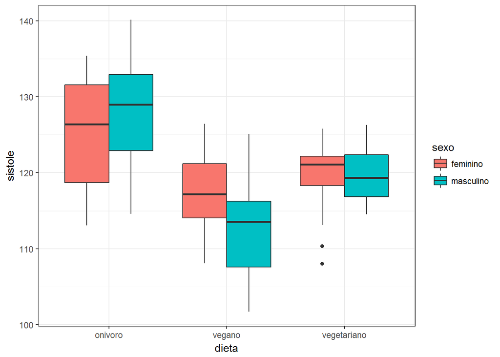

```r
p<-ggplot(dados, aes(x=dieta, y=sistole, fill=sexo))+
  geom_boxplot()+theme_bw()
p
```

E vocC* pode completar, descrevendo no grC!fico quais grupos foram formados, baseando-se nos resultados do `cld()`:

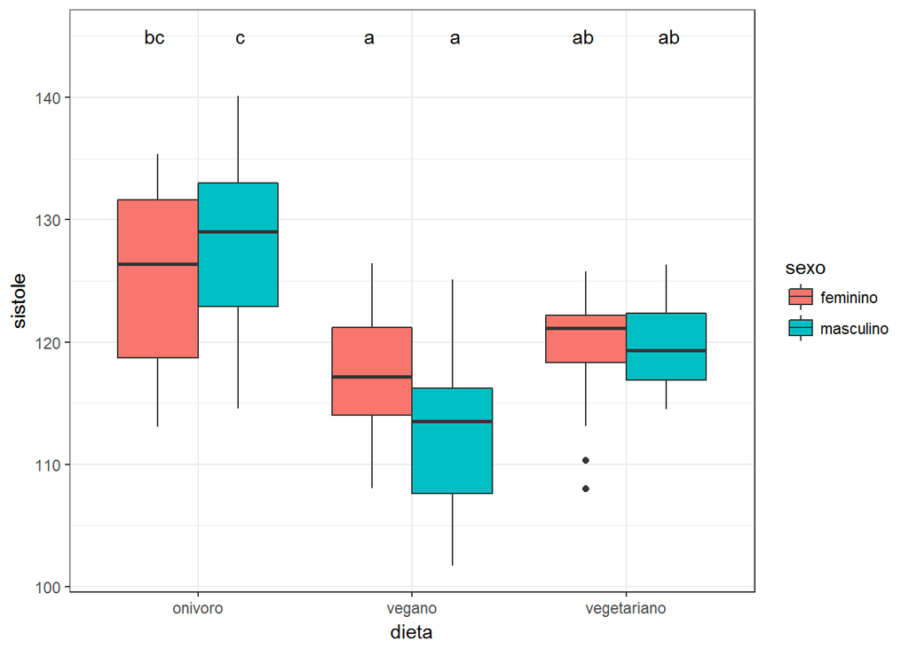

```r
p+annotate("text", label=c("bc","c",  # onivoro m e f
                            "a","a",  # vegano m e f
                            "ab","ab"), # vegetariano m e f
           x=c(0.8, 1.2, 1.8, 2.2, 2.8, 3.2), y=145) # para posicionar as letras
```

Lembre-se que o teste da interaC'C#o **nC#o foi significativo**, portanto, **nC#o C) correto colocar as letras dos agrupamentos segundo a interaC'C#o!**

O grC!fico correto seria:

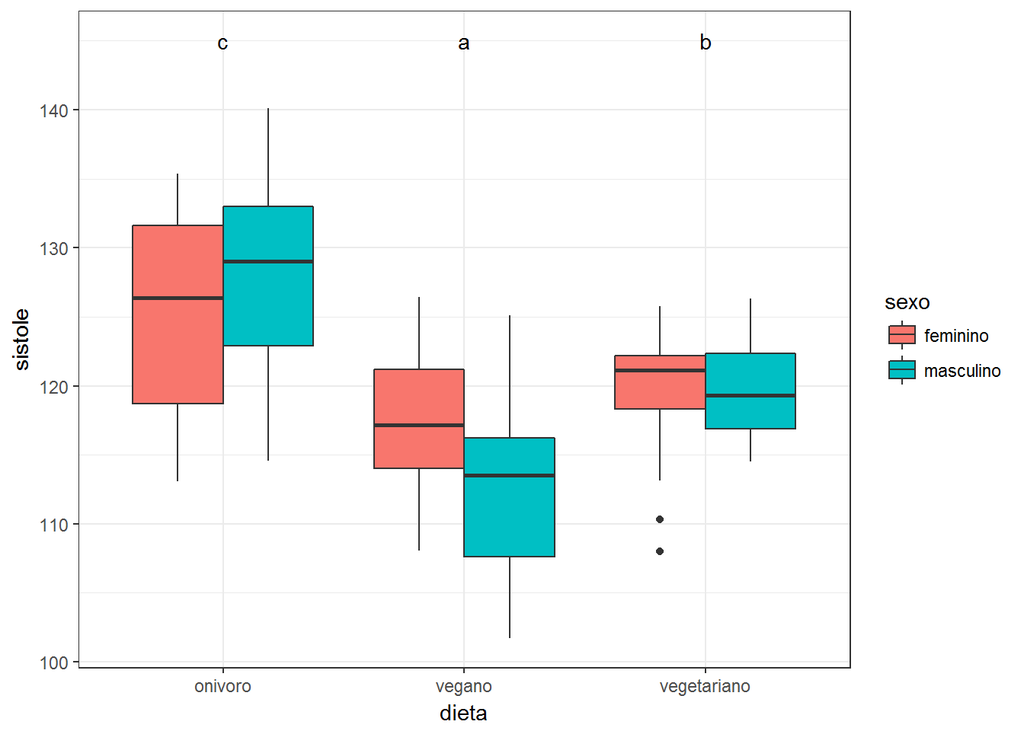

```r
p+annotate("text", label=c("c",  # onivoro m e f
                            "a",  # vegano m e f
                            "b"), # vegetariano m e f
           x=c(1, 2, 3), y=145) # para posicionar as letras
```

Onde somente o fator `dieta` apresentou diferenC'a significativa.

# Agora faC'a vocC* mesmo

## ANOVA one way:

1. Leia o arquivo
2. Analise o balanceamento da amostragem para o fator `size`
3. Verifique se os dados `use` seguem a distribuiC'C#o normal entre as categorias de `size`
4. Verifique a homocedasticidade da variC!vel `use` em relaC'C#o ao fator `size`
5. Execute ANOVA *one way*, onde a variC!vel `use` ~ `size`
6. Avalie os resC-duos do teste.
7. Conclua sobre a ANOVA. Deve ser executado um teste *post hoc*?
8. Se for necessC!rio, execute um teste *post hoc*.
9. Conclua.
10. Construa um grC!fico *boxplot*

## ANOVA two way

1. Leia o arquivo
2. Analise o balanceamento da amostragem entre os fatores `size` e `type`
3. Verifique se os dados `use` seguem a distribuiC'C#o normal para os fatores supracitados
4. Verifique a homocedasticidade da variC!vel em relaC'C#o aos fatores `size` e `type`
5. Execute ANOVA *two way* `use` ~ `size` + `type` + `size:type`
6. Avalie os resC-duos do teste.
7. Conclua sobre a ANOVA. Deve ser executado um teste *post hoc*?
8. Se for necessC!rio, execute um teste *post hoc*.
9. Conclua.
10. Construa um grC!fico *boxplot*